# Currency Exchange Rates with Bayesian

Author

Priscilla Chen

## Introduction

Understanding the factors that drive currency exchange rate fluctuations is critical for policymakers, investors, and businesses engaged in international trade. The exchange rate between the Chinese Yuan (CNY) and the United States Dollar (USD) is a closely watched economic indicator, reflecting complex interactions between the two large economies. This analysis will focus on macroeconomic predictors – interest rate differentials (percentage differences), inflation rate differentials (percentage differences), and GDP growth differentials (percentage differences) – aiming to explore which macroeconomic predictors contribute to changes in the USD/CNY exchange rate (percentage differences) and to what degree. A Bayesian approach enables the incorporation of prior knowledge and probabalistic inference, which is suitable for the dynamic economies.

### Main Question:

How do Differentials in Interest rates, Inflation, and Country’s economical Growth impact the currency exchange rate between US dollars and Chinese Yuan?

### Data Preperation

Data file 1: Monthly Exchange Rate between US dollars and Chinese Yuan, extracted from [Federal Researve](https://www.federalreserve.gov/releases/h10/current/) (Data range from 1990-2 to 2025-2)

Data File 2: Inflation: YEARLY Consumer Prices for USA from [Federal Reserve Bank of St. Louis](https://fred.stlouisfed.org/series/FPCPITOTLZGUSA). (Note this dataset only contain data till 2023)

Data File 3: Inflation: YEARLY Consumer Prices for China from [Federal Reserve Bank of St. Louis](https://fred.stlouisfed.org/series/FPCPITOTLZGCHN). (Note this dataset only contain data till 2023)

Data File 4: Monthly GDP Ratio to Trend for USA, downloaded from [Federal Reserve Bank of St. Louis](https://fred.stlouisfed.org/series/USALORSGPRTSTSAM). (Note this dataset only contain data till 2023-11-01)

Data File 5: Monthly GDP Ratio to Trend for China, downloaded from [Federal Reserve Bank of St. Louis](https://fred.stlouisfed.org/series/CHNLORSGPRTSTSAM). (Note this dataset only contain data till 2024-02-01)

Data file 6: Monthly US Interest Rate (Rates which Federal Reserve charge on banks for overnight borrow), downloaded from [Federal Reserve Bank of St. Louis](https://fred.stlouisfed.org/series/INTDSRUSM193N). (Note this dataset only contain data till 2021-08-01)

Data file 7: Monthly Chinese Interest Rate (Rates which Federal Reserve charge on banks for overnight borrow), downloaded from [Federal Reserve Bank of St. Louis](https://fred.stlouisfed.org/series/INTDSRCNM193N)

**Joined Data:**

```r
datasets <- list(Exchange_rate,GDP_CN,GDP_US, monthly_inflation_CN, monthly_inflation_US, Interest_CN, Interest_US)

data <- reduce(datasets, full_join, by = "observation_date")

data <- data|>
  mutate(Dif_GDP = GDP_US - GDP_CN,
         Dif_Interest_Rate = Interest_US - Interest_CN,
         Dif_Inflation_Rate = Monthly_Inflation_US - Monthly_Inflation_CN)|>
  # "first difference"
  mutate(delta_exch_rate = Exchange_rate - lag(Exchange_rate))
# get rid of the first two row because there's some missing data.
data <- data[-c(1, 2), ]
# glimpse(data)

# scaling all variables other than observation_date.
scaled_data <- data %>%
  mutate(across(
    .cols = where(is.numeric),
    .fns = ~ scale(.) %>% as.vector
  ))

scaled_data <- scaled_data |>
  select(Dif_GDP, Dif_Interest_Rate, Dif_Inflation_Rate, delta_exch_rate)

data_with_na <- scaled_data

scaled_data <- na.omit(scaled_data)
scaled_data <- scaled_data %>%
  filter(delta_exch_rate <= 15)

glimpse(scaled_data)
```

```
Rows: 376
Columns: 4
$ Dif_GDP            <dbl> 2.9877504, 3.0069406, 2.9558031, 2.8366741, 2.64992…
$ Dif_Interest_Rate  <dbl> -1.322479e-01, -1.322479e-01, -1.322479e-01, -1.322…
$ Dif_Inflation_Rate <dbl> 0.71388895, 0.68893880, 0.66398865, 0.63903850, 0.6…
$ delta_exch_rate    <dbl> -0.040066769, -0.040066769, -0.040066769, -0.040066…
```

A first difference calculation is applied to the response variable Exchange Rate because the later exchange rate might be heavily dependent on previous exchange rate. Therefore, the change in exchange rate is calculated as Delta Exchange Rate. Additionally, all predictors and response variables – Interest Rate Differentials (USD - CNY), Inflation Rate Differentials (USD - CNY), GDP Differentials(USD - CNY), and Delta Exchange Rate are standardized.

## Casual Diagram:

[Economics Help](https://www.economicshelp.org/macroeconomics/exchangerate/factors-influencing/) listed 5 factors that would affect exchange rate: rate of growth (GDP), Interest rate, Inflation rate, Competitiveness, and Speculations. Since competitiveness and Speculations are hard to measure quantitatively, they are not included.

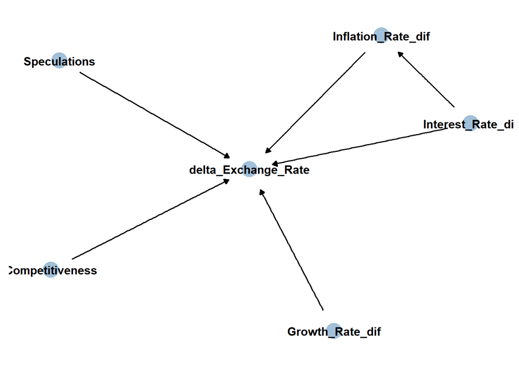

```r
causal_diagram <- dagitty("dag{
  Interest_Rate_dif -> delta_Exchange_Rate;
  Inflation_Rate_dif -> delta_Exchange_Rate;
  Interest_Rate_dif -> Inflation_Rate_dif;
  Growth_Rate_dif -> delta_Exchange_Rate;
  Competitiveness -> delta_Exchange_Rate;
  Speculations -> delta_Exchange_Rate;
}")
gg_dag(causal_diagram)
```

## Model Description

$$\text{Exchange Rate Difference Scaled} \sim \text{Normal}(\mu_i, \sigma)$$
$$\mu_i \sim \beta_0 + \beta_1 * \text{Interest Rate Differential Scaled} + \beta_2 * \text{Inflation Rate Differential Scaled} + \beta_3 * \text{Growth Rate Differential Scaled}$$
$$\beta_0 \sim \text{Normal}(0,1)$$
$$\beta_1 \sim \text{Normal}(0.5,1)$$
$$\beta_2 \sim \text{Normal}(-0.5,1)$$
$$\beta_3 \sim \text{Normal}(0.5,1)$$
$$\sigma \sim \text{Exponential}(1)$$

## Rationals for Prior

Among the key determinants, differentials in interest rates, inflation rates, and gross domestic product growth between US and China have been widely studied as fundamental economic forces influencing currency exchange values. Prior research with Autoregressive distributed lag (ARDL) model indicates that gross domestic product growth have a positive effect on the exchange rate between USD and CNY, while interest rate and inflation rates have a negative effect (Khan, M.K.,2019). While most research agrees on the positive effect of GDP/economic growth and the negative effects of inflation rate toward exchange rate, findings on the relationship between interest rate and currency exchange rate is equivocal. Some studies suggest that an increase in US Federal Reserve’s interest rate would lead to depreciation of CNY and appreciation in USD (Zhou and Zhang, Li).

Since higher inflation rate may depreciate the currency and thus lowers the exchange rate, if scaled Dif_inflation_rate increases, scaled delta_dif_exchange_rate should decrease. I’m using a normal distribution center at -0.5 and has the standard deviation of 1. This means that for one standard deviation increase in scaled differential in inflation rate, I suspect the scaled differential in delta exchange rate will most likely decrease by 0.5 standard deviation. However, there’s still possibility for a wide range of positive and negative slopes.

Since there are ambivalent findings on the relationship between interest rate and exchange rate, but more studies lean toward a positive relationship, theorizing a higher interest rate attract foreign investers and drive up demand for the currency (Li). Therefore, if scaled dif_interest_rate (US - CN) increases, scaled delta_dif_exchange_rate will increase, meaning US currency will worth more in China currency. For its slope, beta 1, I’m using a normal distribution center at 0.5 and has the standard deviation of 1. This means that for one standard deviation increase in differential in interest rate, the delta differential in exchange rate will most likely increase by 0.5 standard deviation. However, there is still possibility for a wider range of slope from negative to positive.

GDP measures growth. The better the growth, the better the currency for it attracts foreign investers, driving up the needs for the currency(Khan, M.K.). Therefore, if scaled Dif_GDP increase, scaled delta_dif_exchange_rate should also increase. For the slope for Dif_GDP, Beta 3, I’m using a normal distribution centering at 0.5 with standard deviation of 1. This prior suggests a likely possitive relationship between GDP and exchange rate, but still keep the possibility for a wide range of both positive and negative values.

I suspect that if all the above are kept at 0, there would be no change in exchange rate. Therefore I used a normal distribution that centers at 0 with standard deviation of 1 for Beta 0, the intercept.

I’m using exponential(1) as the prior for sigma, with lower bound at 0, because the standard deviation cannot be 0.

## Prior Predictive Distribution

```r
n_sim <- 500


predictors <- scaled_data |>
  select(Dif_Interest_Rate, Dif_Inflation_Rate, Dif_GDP) |>
  rename(interest = Dif_Interest_Rate,
         inflation = Dif_Inflation_Rate,
         growth = Dif_GDP) |>
  mutate(obs_id = row_number())

priors <- tibble(
  sim_id = 1:n_sim,
  beta_0 = rnorm(n_sim, 0, 1),
  beta_1 = rnorm(n_sim, 0.5, 1),
  beta_2 = rnorm(n_sim, -0.5, 1),
  beta_3 = rnorm(n_sim, 0.5, 1),
  sigma = rexp(n_sim, 1)
)

prior_pred <- crossing(priors, predictors) |>
  mutate(
    mu = beta_0 + beta_1 * interest + beta_2 * inflation + beta_3 * growth,
    y_sim = rnorm(n(), mean = mu, sd = sigma)
  )|>
  ungroup()
```

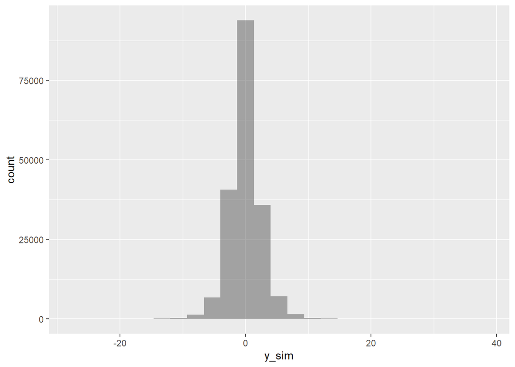

```r
gf_histogram(~y_sim,
             data = prior_pred)
```

The prior predictive distribution show the simulated delta_exchange_rate differences centers at 0, and have a range from about -12 to 12, which is large for a scaled z-score variable, but this wide range can make sure we don’t exclude possible values.

**Main Predictor: Interest Rate**

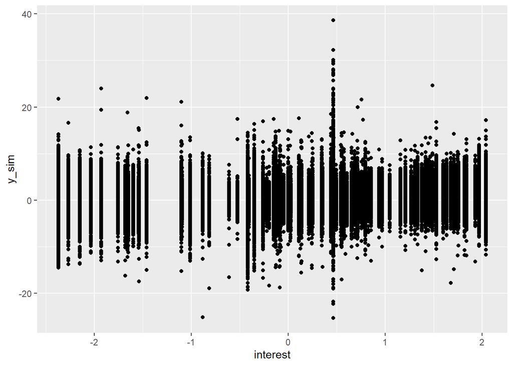

```r
gf_point(y_sim ~ interest, data = prior_pred)
```

The graph above shows distribution of y_sim in relation to the main predictor, Interest Rate. The y_sim values centers around 0, which is expected because all predictors and response variables are standardized.

## Fitting Model

```r
stan_data <- compose_data(scaled_data)
# fit the model
All3predictor_model <- rstan::stan(file = 'model1.stan', data = stan_data)
```

```r
summary(All3predictor_model, pars = c("sigma", "b0", "b1", "b2", "b3"))
```

```
$summary
             mean      se_mean         sd        2.5%         25%         50%
sigma  0.29690657 0.0001605807 0.01083426  0.27666974  0.28932190  0.29671816
b0    -0.06188067 0.0002287625 0.01526848 -0.09310200 -0.07217159 -0.06173892
b1    -0.07027118 0.0004224249 0.02248681 -0.11518709 -0.08485978 -0.07056904
b2     0.03054780 0.0004089559 0.02362109 -0.01544050  0.01450108  0.03101861
b3     0.07671046 0.0002578036 0.01664314  0.04376053  0.06579419  0.07678085
              75%       97.5%    n_eff      Rhat
sigma  0.30400457  0.31904647 4552.095 1.0001507
b0    -0.05155022 -0.03178943 4454.732 0.9994875
b1    -0.05460954 -0.02679263 2833.719 1.0003601
b2     0.04593962  0.07761699 3336.160 0.9996179
b3     0.08771087  0.10890895 4167.664 1.0000728

$c_summary
, , chains = chain:1

         stats
parameter        mean         sd        2.5%         25%         50%
    sigma  0.29743674 0.01130067  0.27658019  0.28967033  0.29708964
    b0    -0.06181250 0.01498685 -0.09228716 -0.07199850 -0.06121956
    b1    -0.07011318 0.02317577 -0.11411812 -0.08644274 -0.07045999
    b2     0.03048767 0.02460855 -0.01829068  0.01417404  0.03143438
    b3     0.07680552 0.01671544  0.04387007  0.06526417  0.07670430
         stats
parameter         75%       97.5%
    sigma  0.30451536  0.32080087
    b0    -0.05164514 -0.03298282
    b1    -0.05395479 -0.02419522
    b2     0.04648631  0.07928615
    b3     0.08826634  0.10887430

, , chains = chain:2

         stats
parameter        mean         sd        2.5%         25%         50%
    sigma  0.29645289 0.01079713  0.27666746  0.28856964  0.29627878
    b0    -0.06162920 0.01555436 -0.09212750 -0.07234382 -0.06221803
    b1    -0.07094903 0.02303916 -0.11608363 -0.08604580 -0.07179491
    b2     0.03101811 0.02334168 -0.01271404  0.01437069  0.03126249
```

[output cut: 27 more lines]

```

         stats
parameter        mean         sd        2.5%         25%         50%
    sigma  0.29686838 0.01057864  0.27697625  0.28946531  0.29677255
    b0    -0.06154695 0.01535529 -0.09275728 -0.07220528 -0.06128847
    b1    -0.07080211 0.02265995 -0.11562567 -0.08541328 -0.07114217
    b2     0.03060022 0.02390927 -0.01504392  0.01486563  0.03073599
    b3     0.07718831 0.01649595  0.04213371  0.06711865  0.07773748
         stats
parameter         75%       97.5%
    sigma  0.30374430  0.31809336
    b0    -0.05143713 -0.03059711
    b1    -0.05518184 -0.02626345
    b2     0.04536952  0.07896392
    b3     0.08771455  0.10725107
```

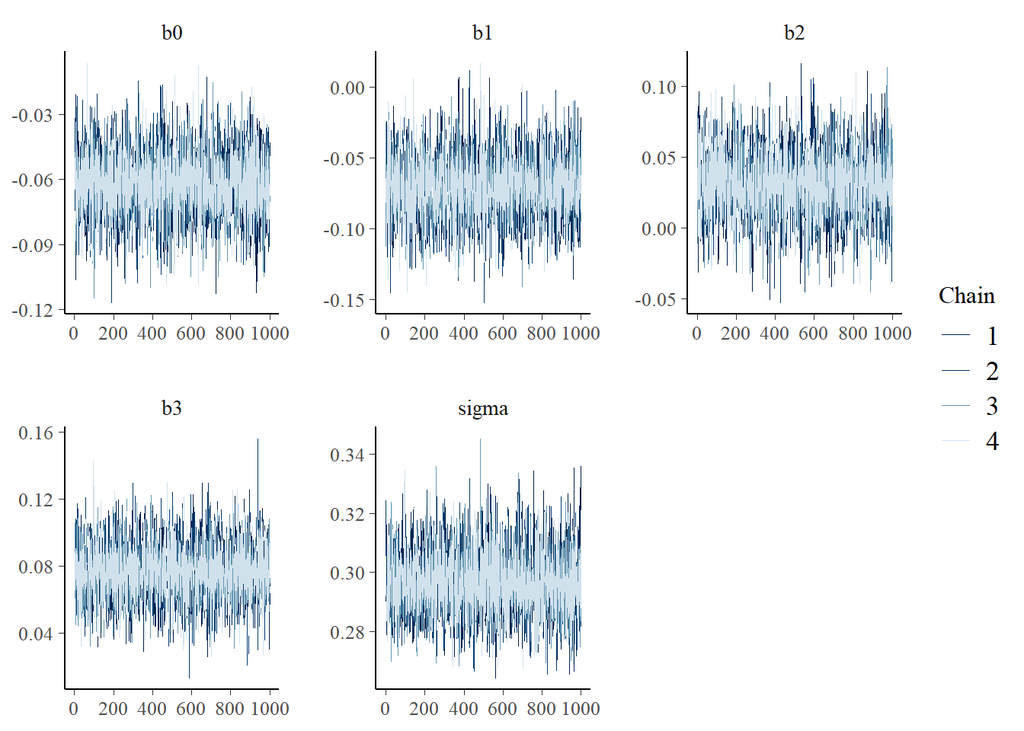

```r
bayesplot::mcmc_trace(All3predictor_model, pars = c("b0", "b1", "b2", "b3","sigma"))
```

## Model Diagnosis

**n_eff:** n_eff is effective number of samples drawn which is an estimate of the number of independent samples from the posterior distribution. The model above displays large n_eff numbers, which suggests that my posterior estimates are based on a sufficient number of effective samples. Using a default stan setting, the model includes 4 chains, 2000 iterations and 1000 warm-up per chain, totalling to 4000 post warm-up samples. The n_eff for the model ranges from ~3000 to ~5000, indicating low autocorrelation and higher independence and suggesting the model could yield reliable results for inference.

**Rhat:** reached exactly 1 for the model above, meaning the chain converge and well-mixed, indicating a good model.

**Trace Plot:** The trace plot demonstrate the following aspects, indicating the model above is good to draw conclusions from.

- Stationary: the path of each chain staying within the same high-probability portion of the posterior distribution. In the plot, the zigzag traces all stays relatively around a stable central tendency.
- Good-Mixing: the zigzag show that the chain doesn’t slowly wander, but rather rapidly explores the full region.
- Convergence: multiple, independent chains stick around the same region of high probability.

## Model Comparison

I fitted a few models with less predictors:

- Inflation_GDP: Model with predictors: scaled Inflation Rate Differential and scaled GDP Differential
- Interest_GDP: Model with predictors: scaled Interest Rate Differential and scaled GDP Differential
- Interest_Inflation: Model with predictors: scaled Interest Rate Differential and scaled Inflation Rate Differential

```r
scaled_data2 <- scaled_data|>
  select(Dif_Inflation_Rate, Dif_GDP, delta_exch_rate)
stan_data2 <- compose_data(scaled_data2)
# model without Differential in Interest Rate predictor
Inflation_GDP <- rstan::stan(file = 'model2.stan', data = stan_data2)
```

[output not shown]

[output not shown]

```r
# without Dif_Inflation_Rate
scaled_data3 <- scaled_data|>
  select(Dif_Interest_Rate, Dif_GDP, delta_exch_rate)
stan_data3 <- compose_data(scaled_data3)
# model without Differential in Inflation Rate predictor
Interest_GDP <- rstan::stan(file = 'model3.stan', data = stan_data3)
```

[output not shown]

[output not shown]

[output not shown]

[output not shown]

```r
# without GDP
scaled_data4 <- scaled_data|>
  select(Dif_Interest_Rate, Dif_Inflation_Rate, delta_exch_rate)
stan_data4 <- compose_data(scaled_data4)
# model without Differential in GDP predictor
Interest_Inflation <- rstan::stan(file = 'model4.stan', data = stan_data4)
```

[output not shown]

[output not shown]

[output not shown]

[output not shown]

[output not shown]

[output not shown]

**WAIC**

```r
# Model Comparison
rethinking::compare(All3predictor_model,Inflation_GDP,Interest_GDP,Interest_Inflation, func = WAIC)
```

```
                        WAIC       SE      dWAIC      dSE    pWAIC       weight
All3predictor_model 162.1469 66.44180  0.0000000       NA 8.855059 5.984300e-01
Interest_GDP        163.0034 66.21954  0.8565222 2.169370 8.650329 3.899617e-01
Inflation_GDP       170.0445 65.38257  7.8975726 4.202447 8.090624 1.153658e-02
Interest_Inflation  180.2038 67.32589 18.0568578 8.611987 7.610222 7.178215e-05
```

**PSIS**

```r
# Model Comparison
rethinking::compare(All3predictor_model,Inflation_GDP,Interest_GDP,Interest_Inflation, func = PSIS)
```

```
Some Pareto k values are high (>0.5). Set pointwise=TRUE to inspect individual points.
```

```
                        PSIS       SE     dPSIS      dSE    pPSIS       weight
All3predictor_model 162.2797 66.57079  0.000000       NA 8.921465 5.799493e-01
Interest_GDP        162.9821 66.28827  0.702350 2.168912 8.639649 4.082034e-01
Inflation_GDP       170.0740 65.47475  7.794251 4.210632 8.105370 1.177307e-02
Interest_Inflation  180.2060 67.41210 17.926263 8.605167 7.611330 7.425941e-05
```

The standard errors are very high, suggesting large overlap between the model preformances. Therefore its results are not reliable in indicating which model preforms better.

## Posteriors

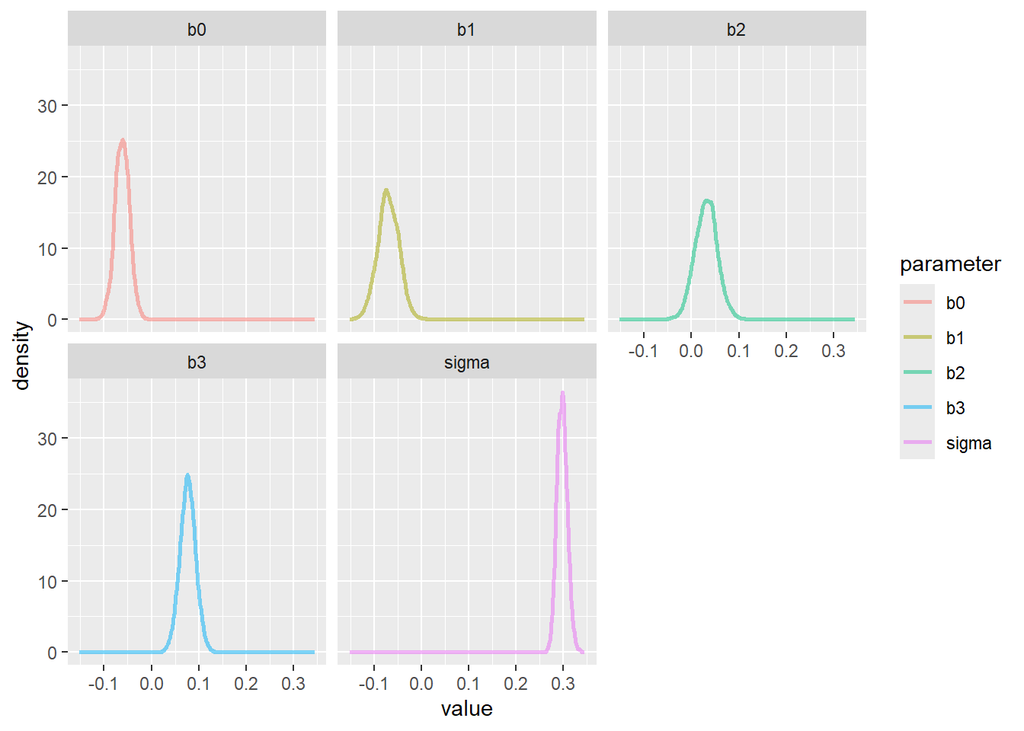

```r
posterior_samples <- as.data.frame(All3predictor_model)

posterior_long <- posterior_samples %>%
  pivot_longer(cols = c(b0, b1, b2, b3, sigma), names_to = "parameter", values_to = "value")

gf_dens(~value | parameter, data = posterior_long, group = ~parameter, color = ~parameter, size = 1)
```

## Interpret Posterior:

**Interest Rate**

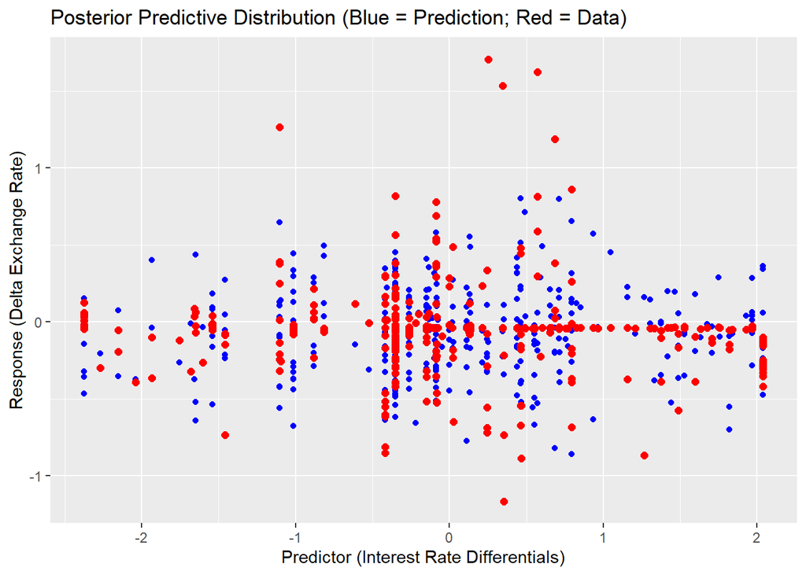

```r
one_draw <- posterior_samples[1, ]

pred_grid <- tibble(
  Interest = scaled_data$Dif_Interest_Rate,
  Inflation_Rate = scaled_data$Dif_Inflation_Rate,
  GDP = scaled_data$Dif_GDP,
  y_pred = rnorm(
    n = nrow(scaled_data),
    mean = one_draw$b0 +
           one_draw$b1 * Interest +
           one_draw$b2 * Inflation_Rate +
           one_draw$b3 * GDP,
    sd = one_draw$sigma
  )
)


gf_point(y_pred ~ Interest, data = pred_grid, color = "blue") %>%
  gf_point(delta_exch_rate ~ Dif_Interest_Rate, data = scaled_data, color = "red", size = 2) %>%
  gf_labs(
    title = "Posterior Predictive Distribution (Blue = Prediction; Red = Data)",
    x = "Predictor (Interest Rate Differentials)",
    y = "Response (Delta Exchange Rate)"
  )
```

**Inflation Rate**

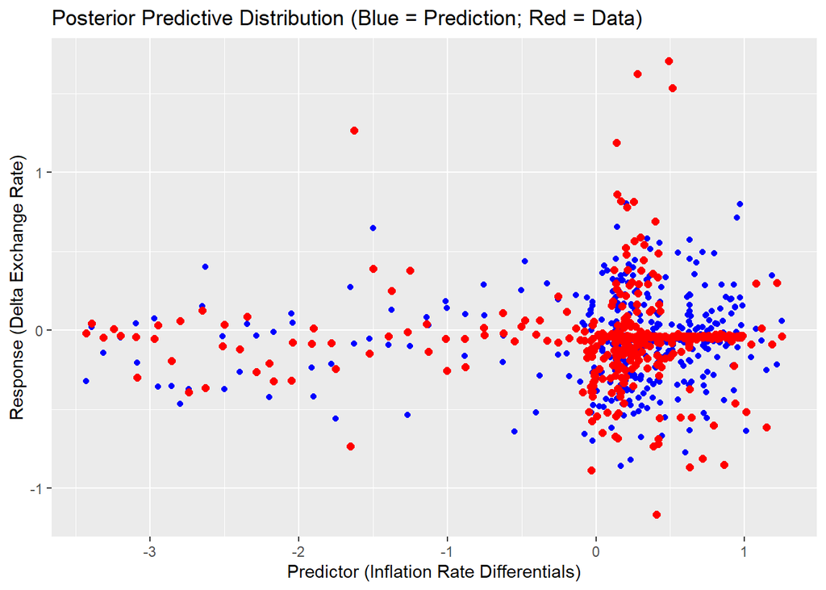

```r
gf_point(y_pred ~ Inflation_Rate, data = pred_grid, color = "blue") %>%
  gf_point(delta_exch_rate ~ Dif_Inflation_Rate, data = scaled_data, color = "red", size = 2) %>%
  gf_labs(
    title = "Posterior Predictive Distribution (Blue = Prediction; Red = Data)",
    x = "Predictor (Inflation Rate Differentials)",
    y = "Response (Delta Exchange Rate)"
  )
```

**GDP**

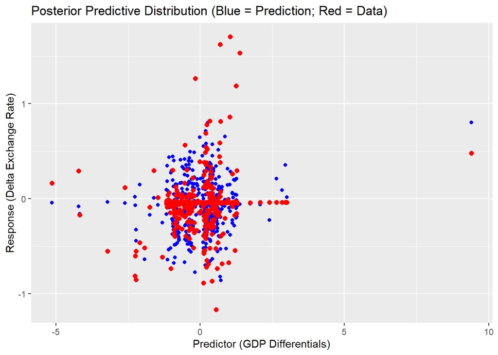

```r
gf_point(y_pred ~ GDP, data = pred_grid, color = "blue") %>%
  gf_point(delta_exch_rate ~ Dif_GDP, data = scaled_data, color = "red", size = 2) %>%
  gf_labs(
    title = "Posterior Predictive Distribution (Blue = Prediction; Red = Data)",
    x = "Predictor (GDP Differentials)",
    y = "Response (Delta Exchange Rate)"
  )
```

b3 centers around 0.08, suggesting that 1 standard deviation increase in the differentials in GDP (US - CN) is correlated with 0.08 increase in exchange rate. In other words, as US experience a higher economic growth than China, measured by GDP, the value of US dollars will slightly increase in terms of Chinese Yuan currency. However, as the graph suggests, the variance is high, suggesting high uncertainty of this finding.

## Work Cited

Khan, M.K., Teng, JZ. & Khan, M.I. *Cointegration between macroeconomic factors and the exchange rate USD/CNY.* Financ Innov 5, 5 (2019). https://doi.org/10.1186/s40854-018-0117-x

Li, Jie. *The Impact of the Interest Rates Raised by Federal Reserve System on the Exchange Rate of the US Dollar Against the Chinese Yuan.* 2023, https://www.researchgate.net/publication/376131422.

Zhou, Hao, and Qiang Zhang. *Analysis of Interest Rate Hikes and Exchange Rate Between U.S. and China.* 2023, https://www.researchgate.net/publication/376132090.